# Analysis of gpt-5.4-mini Data: Financial Analyst Hiring Scenario

Published

August 21, 2026

# Packages & Setup

```r
library(dplyr)
library(ggplot2)
library(lmtest)
library(marginaleffects)
library(purrr)
library(sandwich)
library(stringr)
library(tidyr)

# load custom functions for modeling, plotting, etc.
source(here::here("code/R/tools.r"))

theme_set(theme_nice())

# font setup:
# for the plots used in the paper, we use times new roman font, but this
# part depends on the specific local font setup/paths; not running/rendering
# this everytime
#
# library(showtext)
# library(sysfonts)
#
# font_add(
#   "TimesNewRoman",
#   regular = "/usr/share/fonts/truetype/msttcorefonts/Times_New_Roman.ttf",
#   bold = "/usr/share/fonts/truetype/msttcorefonts/Times_New_Roman_Bold.ttf"
# )
#
# showtext_auto()
# theme_set(theme_nice(base_family = "TimesNewRoman"))
```

# Data

```r
chatty <- readr::read_csv(here::here("perma_data/Scenarios/FinacialAnalyst/chatgpt.csv"))
```

```r
chatty <-
  chatty |>
  mutate(
    across(gender:experience, factor),

    # Baselines:

    race = factor(race, levels = c("White", "Black", "Hispanic", "Asian")),
    gender = factor(gender, levels = c("Male", "Female", "Non-binary")),
    disability_status = factor(
      disability_status,
      levels = c(
        "None stated",
        "Physical disability",
        "Mental health history"
      )
    ),
    experience = factor(
      experience,
      levels = c(
        "0-2 years",
        "3-7 years",
        "10+ years"
      )
    )
  )
```

# Unconditional estimates

## AMCEs

```r
amce_res <- amce(
  chosen ~ gender + age + race + disability_status +
    nationality + education + field_of_study + cover_letter +
    recommendations + experience,
  data = chatty
)

amce_res
```

```
# A tibble: 35 × 9
   term      estimate std.error statistic  p.value    lower    upper level attr
   <chr>        <dbl>     <dbl>     <dbl>    <dbl>    <dbl>    <dbl> <chr> <chr>
 1 genderFe…  0.00792   0.00369     2.14  3.20e- 2  0.00423  1.16e-2 Fema… gend…
 2 genderNo…  0.00588   0.00368     1.60  1.10e- 1  0.00220  9.56e-3 Non-… gend…
 3 age35     -0.00927   0.00529    -1.75  7.95e- 2 -0.0146  -3.98e-3 35    age
 4 age40     -0.0149    0.00528    -2.81  4.88e- 3 -0.0201  -9.58e-3 40    age
 5 age45     -0.0272    0.00529    -5.14  2.76e- 7 -0.0325  -2.19e-2 45    age
 6 age50     -0.0432    0.00521    -8.30  1.11e-16 -0.0484  -3.80e-2 50    age
 7 age55     -0.0471    0.00521    -9.05  1.52e-19 -0.0524  -4.19e-2 55    age
 8 raceBlack -0.0219    0.00425    -5.14  2.72e- 7 -0.0261  -1.76e-2 Black race
 9 raceHisp… -0.00694   0.00426    -1.63  1.04e- 1 -0.0112  -2.68e-3 Hisp… race
10 raceAsian -0.00375   0.00427    -0.879 3.79e- 1 -0.00802  5.16e-4 Asian race
# ℹ 25 more rows
```

Visually:

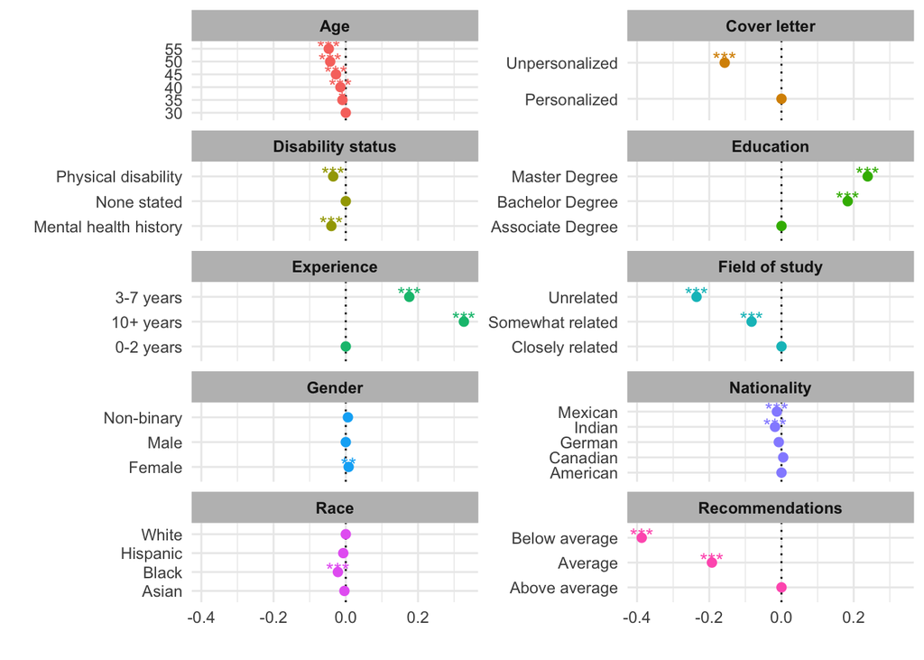

```r
amce_res |>
  mutate(
    attr =
      attr |>
      gsub("_", " ", x = _) |>
      stringr::str_to_sentence(),
    label = stars(p.value)
  ) |>
  ggplot(aes(x = estimate, y = level, color = attr)) +
  geom_vline(aes(xintercept = 0), lty = "dotted") +
  geom_point(size = 2) +
  geom_text(aes(label = label), position = position_nudge(y = .1)) +
  geom_linerange(aes(xmin = lower, xmax = upper), lwd = 1) +
  facet_wrap(~attr, scales = "free_y", ncol = 2) +
  theme(legend.position = "none") +
  labs(x = "", y = "")
```

## Marginal means

```r
mm_res <-mm(
  chosen ~ gender + age + race + disability_status +
    nationality + education + field_of_study + cover_letter +
    recommendations + experience,
  data = chatty
)

mm_res
```

```
# A tibble: 35 × 9
   term           estimate std.error statistic   p.value attr  level lower upper
   <chr>             <dbl>     <dbl>     <dbl>     <dbl> <chr> <chr> <dbl> <dbl>
 1 genderMale        0.197   0.00346      57.1 0         gend… Male  0.194 0.201
 2 genderFemale      0.205   0.00349      58.8 0         gend… Fema… 0.202 0.209
 3 genderNon-bin…    0.199   0.00346      57.7 0         gend… Non-… 0.196 0.203
 4 age30             0.224   0.00510      44.0 0         age   30    0.219 0.229
 5 age35             0.215   0.00501      42.9 0         age   35    0.210 0.220
 6 age40             0.211   0.00496      42.5 0         age   40    0.206 0.216
 7 age45             0.194   0.00491      39.5 0         age   45    0.189 0.199
 8 age50             0.181   0.00474      38.2 2.14e-314 age   50    0.176 0.186
 9 age55             0.178   0.00467      38.2 5.72e-313 age   55    0.173 0.183
10 raceWhite         0.211   0.00405      52.0 0         race  White 0.207 0.215
# ℹ 25 more rows
```

Visually:

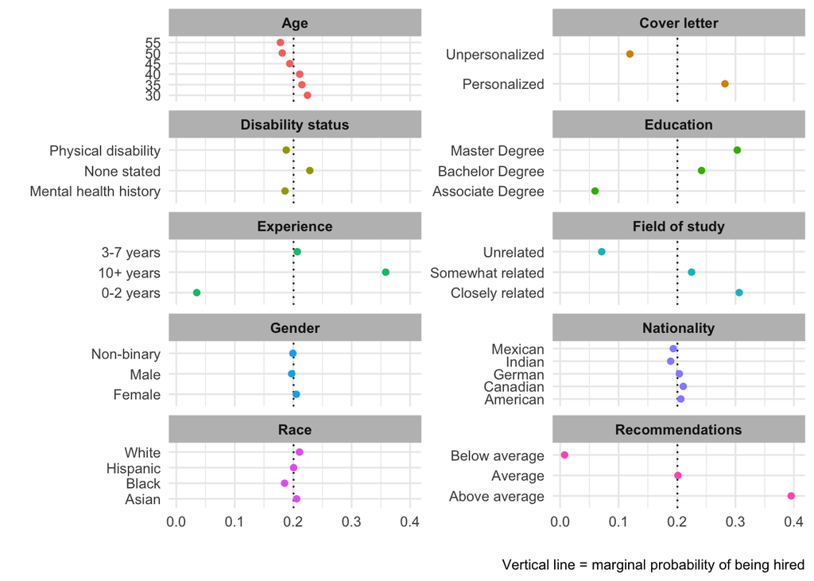

```r
# overall MM/baseline selection prob.:
omean <- mean(chatty$chosen, na.rm = TRUE)

mm_res |>
  mutate(
    attr =
      attr |>
      gsub("_", " ", x = _) |>
      stringr::str_to_sentence()
  ) |>
  ggplot(aes(x = estimate, y = level, color = attr)) +
  geom_vline(aes(xintercept = omean), lty = "dotted") +
  geom_point() +
  geom_linerange(aes(xmin = lower, xmax = upper)) +
  facet_wrap(~attr, scales = "free_y", ncol = 2) +
  theme(legend.position = "none") +
  labs(
    x = "",
    y = "",
    caption = "Vertical line = marginal probability of being hired"
  )
```

## Other checks

### Relative importance

Lindemann, Merenda & Gold (LMG) importance; equivalent to Shapley-decomposition. Basically share of explained variance accountable to each variable. Factor variables are ‘grouped’.

```r
# load the bootstrapped results from a backup below, only run this
# to reproduce (is not re-run on render)

mod_full <- lm(
  chosen ~ education + field_of_study + cover_letter +
    recommendations + experience + gender + age + race +
    disability_status + nationality,
  data = chatty
)

set.seed(42)

rel_imp <- relaimpo::boot.relimp(
  mod_full,
  type = "lmg",
  rela = TRUE,
  boot = 500
)

eval_imp <- relaimpo::booteval.relimp(rel_imp, level = 0.95, sort = TRUE)

eval_imp
```

Cleaning the results:

```r
# same here, not run by default since we load results from a backup below

imp_df <-
  as.data.frame(eval_imp@mark) |>
  setNames(c("percentage", "rating", "lower", "upper")) |>
  tibble::rownames_to_column("variable") |>
  mutate(
    variable = gsub(".lmg", "", variable),
    across(c(percentage, lower, upper), as.numeric),
    group = if_else(
      variable %in% c("race", "age", "disability_status", "gender", "nationality"),
      "Sensitive",
      "Non-sensitive"
    )
  ) |>
  tibble() |>
  select(-rating)

# Export so we do not have to re-run this all the time:
imp_df |> readr::write_csv(here::here("perma_data/Scenarios/FinacialAnalyst/chatty_relimp.csv"))
```

Visually:

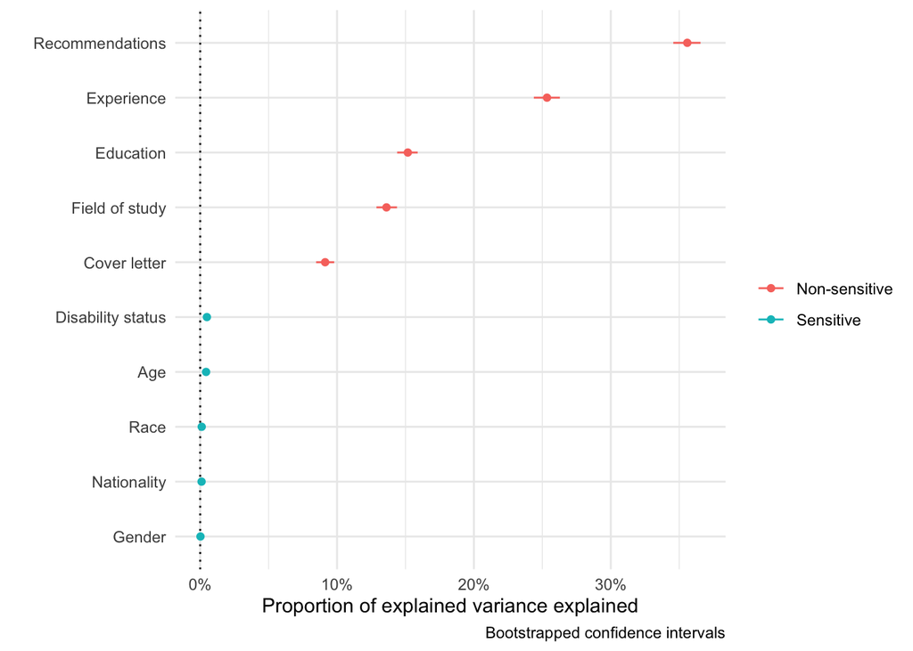

```r
imp_df <- readr::read_csv(here::here("perma_data/Scenarios/FinacialAnalyst/chatty_relimp.csv"))

imp_df |>
  mutate(
    variable = variable |>
      stringr::str_replace_all("_", " ") |>
      stringr::str_to_sentence()
  ) |>
  ggplot(
    aes(
      x = percentage,
      y = forcats::fct_reorder(variable, percentage),
      color = group
    )
  ) +
  geom_vline(xintercept = 0, lty = "dotted") +
  geom_point() +
  geom_linerange(aes(xmin = lower, xmax = upper)) +
  scale_x_continuous(labels = scales::label_percent()) +
  labs(
    x = "Proportion of explained variance explained",
    y = "",
    color = "",
    caption = "Bootstrapped confidence intervals"
  )
```

By sensitive/nonsensitive:

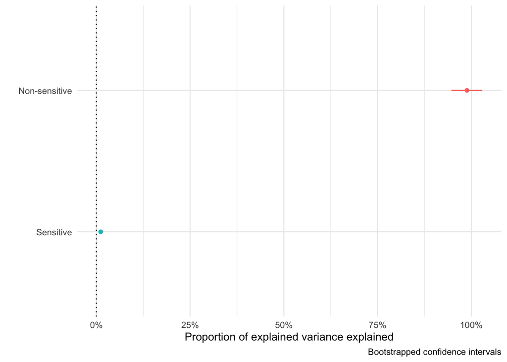

```r
imp_df |>
  group_by(group) |>
  summarise(across(c(percentage, lower, upper), sum)) |>
  ggplot(
    aes(
      x = percentage,
      y = forcats::fct_reorder(group, percentage),
      color = group
    )
  ) +
  geom_vline(xintercept = 0, lty = "dotted") +
  geom_point() +
  geom_linerange(aes(xmin = lower, xmax = upper)) +
  theme(legend.position = "none") +
  labs(
    x = "Proportion of explained variance explained",
    y = "",
    caption = "Bootstrapped confidence intervals"
  ) +
  scale_x_continuous(labels = scales::label_percent())
```

# Intersectional bias

Conceptually, assess two different types of effect dependence. First, conditional effects, e.g.

$$\text{Black}_{\text{Disabled}} - \text{White}_\text{Disabled}$$
Assessing whether disabled candidates have a different probability to be selected when being black vs. when being white, and interaction,

$$(\text{Black}_{\text{Disabled}} - \text{White}_\text{Disabled}) - (\text{Black}_{\text{Able}} - \text{White}_\text{Able})$$
i.e. “does the black vs. white gap differ for respondents differ depending on disability (and vice versa)”?

## Race/Gender

```r
m_race_gender <- lm(chosen ~ race*gender, chatty)
coeftest(m_race_gender, vcov. = vcovHC(m_race_gender, type = "HC2"))
```

```
t test of coefficients:

                                 Estimate  Std. Error t value Pr(>|t|)
(Intercept)                    0.20780372  0.00697680 29.7850  < 2e-16 ***
raceBlack                     -0.02317884  0.00975535 -2.3760  0.01751 *
raceHispanic                  -0.01322541  0.00979255 -1.3506  0.17684
raceAsian                     -0.00586609  0.00987331 -0.5941  0.55242
genderFemale                   0.00927813  0.00995456  0.9320  0.35132
genderNon-binary              -0.00054066  0.00985903 -0.0548  0.95627
raceBlack:genderFemale        -0.00762850  0.01380686 -0.5525  0.58060
raceHispanic:genderFemale     -0.00085344  0.01396111 -0.0611  0.95126
raceAsian:genderFemale         0.00358352  0.01408695  0.2544  0.79920
raceBlack:genderNon-binary     0.00084101  0.01377322  0.0611  0.95131
raceHispanic:genderNon-binary  0.01055525  0.01389127  0.7598  0.44735
raceAsian:genderNon-binary    -0.00085578  0.01393646 -0.0614  0.95104
---
Signif. codes:  0 '***' 0.001 '**' 0.01 '*' 0.05 '.' 0.1 ' ' 1
```

Conditional AMCEs. Among non-binary and female candidates, the model discriminates against black applicants: black non-binaries and black women are significantly less likely to be selected than their white counterparts.

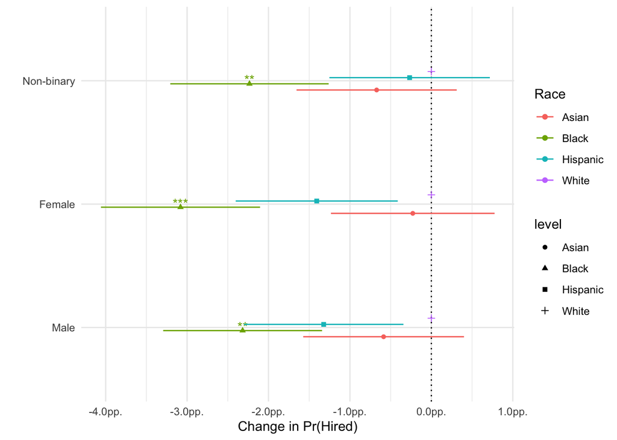

```r
chatty |>
  camce_plot(race, gender) +
  labs(color = "Race")
```

Conditional MMs:

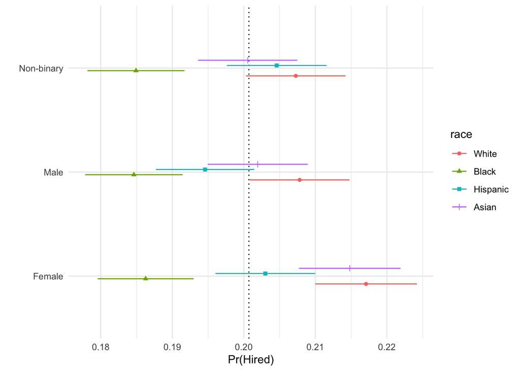

```r
chatty |>
  cmm_plot(gender, race) +
  labs(color = "race")
```

```r
# As Heatmap
#
# cmm_gender_race |>
#   ggplot(aes(x = level, y = race, fill = estimate)) +
#   geom_tile() +
#   scale_fill_distiller(
#     palette = "RdBu",
#     direction = -1,
#     labels = scales::label_percent(suffix = "pp.")
#   ) +
#   theme_minimal()
```

## Gender/Nationality

```r
m_nat_gender <- lm(chosen ~ nationality*gender, chatty)
coeftest(m_nat_gender, vcov. = vcovHC(m_nat_gender, type = "HC2"))
```

```
t test of coefficients:

                                       Estimate Std. Error t value Pr(>|t|)
(Intercept)                           0.1988764  0.0077262 25.7405  < 2e-16 ***
nationalityCanadian                   0.0137650  0.0111823  1.2310  0.21834
nationalityGerman                     0.0023070  0.0109156  0.2114  0.83261
nationalityIndian                    -0.0140530  0.0107849 -1.3030  0.19257
nationalityMexican                   -0.0091561  0.0108542 -0.8435  0.39893
genderFemale                          0.0251632  0.0112181  2.2431  0.02490 *
genderNon-binary                     -0.0017717  0.0108839 -0.1628  0.87069
nationalityCanadian:genderFemale     -0.0363766  0.0158640 -2.2930  0.02185 *
nationalityGerman:genderFemale       -0.0246850  0.0156883 -1.5735  0.11562
nationalityIndian:genderFemale       -0.0096931  0.0155321 -0.6241  0.53258
nationalityMexican:genderFemale      -0.0153941  0.0155636 -0.9891  0.32262
nationalityCanadian:genderNon-binary  0.0067160  0.0157245  0.4271  0.66931
nationalityGerman:genderNon-binary    0.0094772  0.0154643  0.6128  0.53998
nationalityIndian:genderNon-binary   -0.0011993  0.0152025 -0.0789  0.93712
nationalityMexican:genderNon-binary   0.0033124  0.0153587  0.2157  0.82925
---
Signif. codes:  0 '***' 0.001 '**' 0.01 '*' 0.05 '.' 0.1 ' ' 1
```

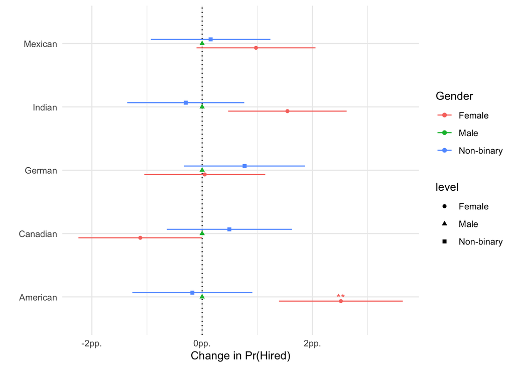

```r
chatty |>
  camce_plot(gender, nationality) +
  labs(color = "Gender")
```

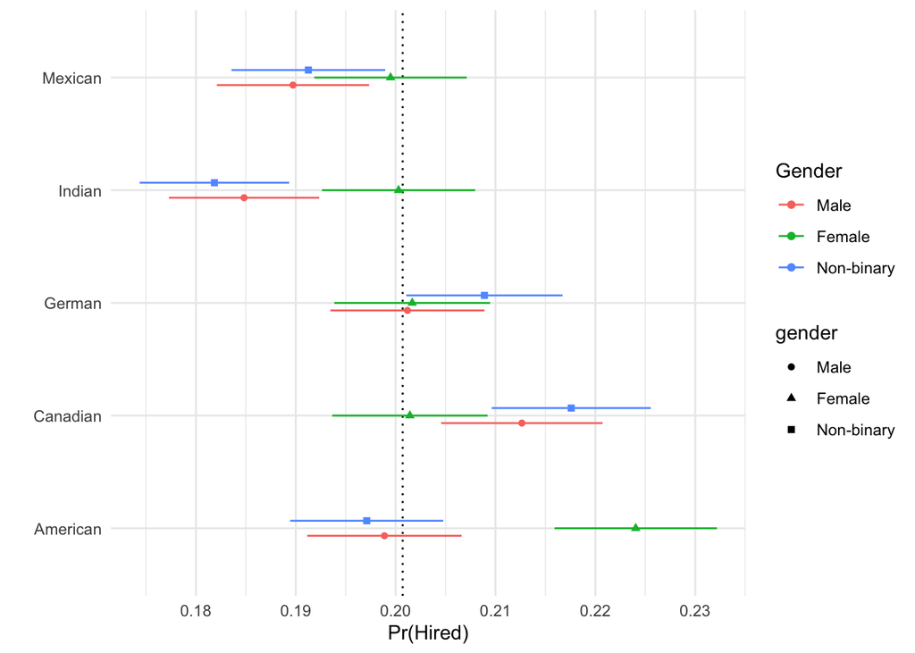

```r
chatty |>
  cmm_plot(nationality, gender) +
  labs(color = "Gender")
```

## Disability/Gender

```r
m_dis_gender <- lm(chosen ~ disability_status*gender, chatty)

res_dis_gender <- coeftest(
  m_dis_gender,
  vcov. = vcovHC(m_dis_gender, type = "HC2")
)

res_dis_gender
```

```
t test of coefficients:

                                                          Estimate Std. Error
(Intercept)                                              0.2173613  0.0062593
disability_statusPhysical disability                    -0.0249408  0.0086163
disability_statusMental health history                  -0.0345463  0.0085215
genderFemale                                             0.0235890  0.0089759
genderNon-binary                                         0.0094521  0.0088640
disability_statusPhysical disability:genderFemale       -0.0311038  0.0122103
disability_statusMental health history:genderFemale     -0.0158214  0.0121835
disability_statusPhysical disability:genderNon-binary   -0.0149588  0.0121823
disability_statusMental health history:genderNon-binary -0.0077130  0.0120547
                                                        t value  Pr(>|t|)
(Intercept)                                             34.7260 < 2.2e-16 ***
disability_statusPhysical disability                    -2.8946  0.003799 **
disability_statusMental health history                  -4.0540 5.044e-05 ***
genderFemale                                             2.6280  0.008591 **
genderNon-binary                                         1.0664  0.286271
disability_statusPhysical disability:genderFemale       -2.5473  0.010859 *
disability_statusMental health history:genderFemale     -1.2986  0.194088
disability_statusPhysical disability:genderNon-binary   -1.2279  0.219487
disability_statusMental health history:genderNon-binary -0.6398  0.522288
---
Signif. codes:  0 '***' 0.001 '**' 0.01 '*' 0.05 '.' 0.1 ' ' 1
```

Nicely format this into a regression table, latex output:

```r
rownames(res_dis_gender) <-
  rownames(res_dis_gender) |>
  str_replace_all(c(
    "disability_status" = "",
    "gender" = "",
    ":" = " × "
  ))

res_dis_gender |>
  #stargazer::stargazer(type = "text")
  stargazer::stargazer(type = "latex")
```

```
% Table created by stargazer v.5.2.3 by Marek Hlavac, Social Policy Institute. E-mail: marek.hlavac at gmail.com
% Date and time: Fri, Aug 21, 2026 - 12:34:35
\begin{table}[!htbp] \centering
  \caption{}
  \label{}
\begin{tabular}{@{\extracolsep{5pt}}lc}
\\[-1.8ex]\hline
\hline \\[-1.8ex]
 & \multicolumn{1}{c}{\textit{Dependent variable:}} \\
\cline{2-2}
\\[-1.8ex] &   \\
\hline \\[-1.8ex]
 Physical disability & $-$0.025$^{***}$ \\
  & (0.009) \\
  & \\
 Mental health history & $-$0.035$^{***}$ \\
  & (0.009) \\
  & \\
 Female & 0.024$^{***}$ \\
  & (0.009) \\
  & \\
 Non-binary & 0.009 \\
  & (0.009) \\
  & \\
 Physical disability × Female & $-$0.031$^{**}$ \\
  & (0.012) \\
  & \\
 Mental health history × Female & $-$0.016 \\
  & (0.012) \\
  & \\
 Physical disability × Non-binary & $-$0.015 \\
  & (0.012) \\
  & \\
 Mental health history × Non-binary & $-$0.008 \\
  & (0.012) \\
  & \\
 Constant & 0.217$^{***}$ \\
  & (0.006) \\
  & \\
\hline \\[-1.8ex]
\hline
\hline \\[-1.8ex]
\textit{Note:}  & \multicolumn{1}{r}{$^{*}$p$<$0.1; $^{**}$p$<$0.05; $^{***}$p$<$0.01} \\
\end{tabular}
\end{table}
```

Females significantly more likely to still be hired than males when both have a mental health history:

[figure not shown]

```r
chatty |>
  camce_plot(gender, disability_status) +
  theme_nice(base_size = 16, base_family = "TimesNewRoman") +
  labs(color = "Gender", shape = "Gender") +
  rcartocolor::scale_color_carto_d(palette = "Prism") +
  theme(
    legend.position = "inside",
    legend.position.inside = c(0.9, 0.7),
    plot.margin = margin(t = 10, r = 20, b = 10, l = 0)
  ) +
  scale_y_discrete(
    labels = (\(x, ...) gsub("\\s", "\n", x))(levels(chatty$disability_status))
    #expand = expansion(add = c(1, 1))
  ) +
  xlim(c(-.04, .04))
```

```r
# ggsave(
#   here::here("writing/tex/figures/gender_disability_chatty.pdf"),
#   width = 5,
#   height = 3
# )
```

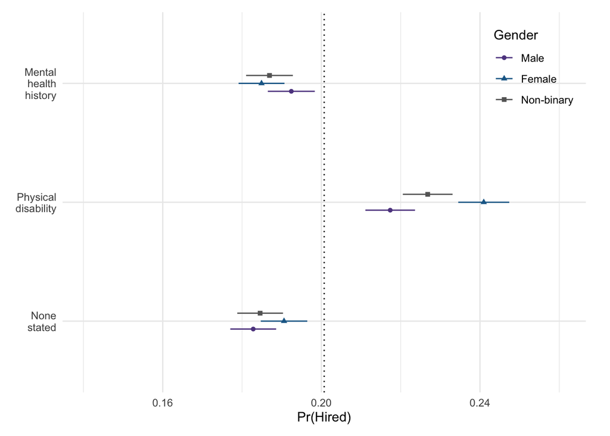

```r
chatty |>
  cmm_plot(disability_status, gender) +
  #theme_nice(base_size = 14, base_family = "TimesNewRoman") +
  labs(color = "Gender", shape = "Gender") +
  rcartocolor::scale_color_carto_d(palette = "Prism") +
  theme(
    legend.position = "inside",
    legend.position.inside = c(0.9, 0.85),
    plot.margin = margin(t = 10, r = 20, b = 10, l = 0)
  ) +
  scale_y_discrete(
    labels = (\(x, ...) gsub("\\s", "\n", x))(levels(chatty$disability_status))
  ) +
  xlim(c(omean - .06, omean + .06))
```

```r
# ggsave(
#   here::here("writing/tex/figures/gender_disability_chatty_mm.pdf"),
#   width = 5,
#   height = 4
# )
```